# NOTE 1: The plyr and ggplot2 packages are required. They must be installed before running the code.

## NOTE 1: The plyr and ggplot2 packages are required. They must be installed before running the code.

## NOTE 2: All referenced figures can be found in the figures folder of the repository

library(plyr) library(ggplot2)

## Loading and preprocessing the data

##The data is from a personal activity monitoring device. This device collects data at 5 minute intervals through out the day. The data consists of two months of data from an anonymous individual collected during the months of October and November, 2012 and include the number of steps taken in 5 minute intervals each day.

## The data is stored in the respository as activity.csv and has a header row in the file. There are three variables: steps = Number of steps taking in a 5-minute interval (missing values are coded as NA); date = The date on which the measurement was taken in YYYY-MM-DD format; interval = Identifier for the 5-minute interval in which measurement was taken (coded as an integer with the convention hhmm corresponding to the hour and start minute of the interval). Much data “cleaning” is done on the fly with the code for the exporatory analysis.

```
activityData <- read.csv("activity.csv",head=TRUE, na.strings="NA",
            colClasses=c("integer","character","integer"))
```

## What is mean total number of steps taken per day?

## The mean steps per day is 10766.19 with a media of 10765 indicating there is not

## much skew to the data. This is mirrored in the histogram StepsPerDay.png (Note: Any day for which the total steps are 0 are removed from the analysis. It is assumed that the device was not properly worn on days where it indicates the person never moved.)

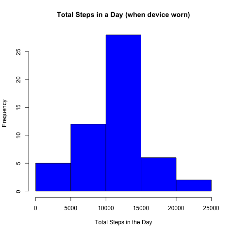

```
## Calculate steps per day, then remove all days with zero steps
stepsPerDay <- tapply(activityData$steps, activityData$date, sum, na.rm=TRUE)
stepsPerDay <- stepsPerDay[which(stepsPerDay > 0)]

## Generate historgram
outfile <- "figure/StepsPerDay.png"
png(outfile)
hist(stepsPerDay, col="blue", main="Total Steps in a Day (when device worn)",
     xlab="Total Steps in the Day", ylab="Frequency")
dev.off()
message(paste("Chart Complete. Stored as ",getwd(),"/",outfile,sep=""))
rm(outfile)

## Calculate averages
stepsPerDayAvg <- c(mean(stepsPerDay), median(stepsPerDay))
names(stepsPerDayAvg) <- c('Mean', 'Median')
print(stepsPerDayAvg)
rm(stepsPerDayAvg)
rm(stepsPerDay)
```

## What is the average daily activity pattern?

## The average pattern of activity shows that peak movement in the morning as seen in StepsThruDay.png. The peak average is at 8:35 with 206 steps.

[figure not shown]

## The imputation has little effec on the data as the distribution of total steps per day is similar in shape as seen in StepsPerDayImputed.png. The mean remained at 10766.19 while one of the imputed days became the median at 10766 also. (small but insignificant shift)

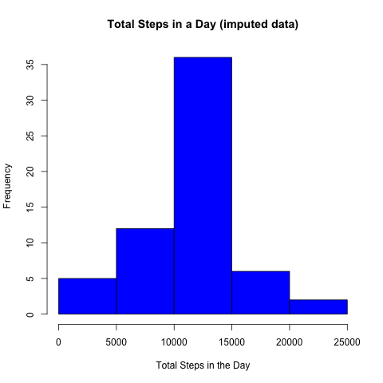

```
message("Indicator table for rows with steps data missing (TRUE = missing)")
t <- table(is.na(activityData$steps))
print(t)
rm(t)

##Calculate interval averages and map onto original data
    stepsPerTime <- ddply(activityData, .(interval), summarize,
                          avgSteps = mean(steps, na.rm=TRUE))
    activityData2 <- join(activityData, stepsPerTime, by = "interval", type = "left",
                          match = "all")
    rm(stepsPerTime)

##Replace missing steps with average for interval
    activityData2$steps[is.na(activityData$steps)] <-
        activityData2$avgSteps[is.na(activityData$steps)]

##tidy up dataset
    activityData2 <- activityData2[ , 1:4]

## Replot Imputed Data to Summarize the average steps taken throughout the day.

    ##Calculate steps per day, then remove all days with zero steps
    stepsPerDay <- tapply(activityData2$steps, activityData2$date, sum, na.rm=TRUE)

    ##Generate historgram
    outfile <- "figure/StepsPerDayImputed.png"
    png(outfile)
    hist(stepsPerDay, col="blue", main="Total Steps in a Day (imputed data)",
         xlab="Total Steps in the Day", ylab="Frequency")
    dev.off()
    message(paste("Chart Complete. Stored as ",getwd(),"/",outfile,sep=""))
    rm(outfile)

    ##Calculate averages
    stepsPerDayAvg <- c(mean(stepsPerDay), median(stepsPerDay))
    names(stepsPerDayAvg) <- c('Mean', 'Median')
    print(stepsPerDayAvg)
    rm(stepsPerDayAvg)
    rm(stepsPerDay)
```

## Are there differences in activity patterns between weekdays and weekends?

##

## There is a clear difference in activity pattern as seen in StepsThruDaybyWeekPortion.png. Weekday steps peak in the morning and are down through the rest of the day with an secondary peak in the evening. Weekend steps rise in the morning and stay at a higher level throughout the day.

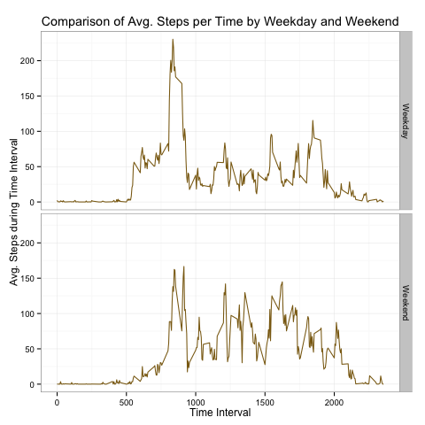

```
##Create Identifier for Weekdays

    #Transform character date into date field
    daysRecorded <- as.POSIXct(activityData2$date, format="%Y-%m-%d")

    ##Get Name of days
    dayNames <- weekdays(daysRecorded)

    ##Initialize array for weekportion inicator to weekday
    weekPortion <- rep("Weekday",length(dayNames))

    ##Recode sunday and saturday to weekend
    weekPortion[dayNames == "Sunday" | dayNames == "Saturday"] <- "Weekend"

    ## Map back onto dataset
    activityData2 <- cbind(activityData2, weekPortion)

    rm(weekPortion)
    rm(dayNames)
    rm(daysRecorded)

##Summarize average time interval steps by week portion
stepsPerTime <- ddply(activityData2, .(interval, weekPortion), summarize,
                      avgSteps = mean(steps, na.rm=TRUE))

##Plot Weekend vs Weekday
    outfile <- "figure/StepsThruDaybyWeekPortion.png"
    png(outfile)

        g <- ggplot(stepsPerTime, aes(interval,avgSteps))
        g <- g + facet_grid(weekPortion ~ .)
        g <- g + geom_line(color="goldenrod4")
        g <- g + xlab("Time Interval")
        g <- g + ylab("Avg. Steps during Time Interval")
        g <- g + ggtitle(expression("Comparison of Avg. Steps per Time by Weekday and Weekend"))
        g <- g + theme_bw()
        print(g)

    dev.off()
    message(paste("Chart Complete. Stored as ",getwd(),"/",outfile,sep=""))
    rm(outfile)
    rm(stepsPerTime)
    rm(g)
```